# Лабораторная работа №8

Матвеева А.С

Российский университет дружбы народов, Москва, Россия

# Информация

## Докладчик

- Матвеева Анастасия Сергеевна
- НБИ-02-22
- РУДН

## Цели и задачи

- Познакомиться с операционной системой Linux. Получить практические навыки рабо- ты с редактором vi, установленным по умолчанию практически во всех дистрибутивах.

## Этапы работы

1. cоздайте каталог с именем ~/work/os/lab08 Перейдите во вновь созданный каталог. Вызовите vi и создайте файл hello.sh

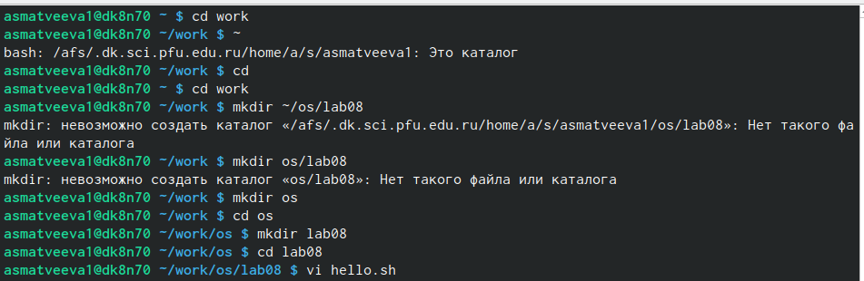

…

2. нажмите клавишу i и вводите следующий текст

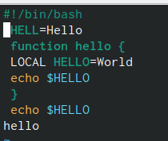

…

3. Нажмите клавишу Esc для перехода в командный режим после завершения ввода текста. Нажмите : для перехода в режим последней строки и внизу вашего экрана появитсяи приглашение в виде двоеточия. Нажмите w (записать) и q (выйти), а затем нажмите клавишу Enter для сохранения вашего текста и завершения работы’

…

4. Сделайте файл исполняемым

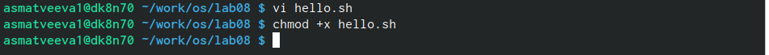

…

5. вызовите vi на редактирование файла

[figure not shown]

…

6. Перейдите в режим вставки и замените на HELLO.. Нажмите Esc для возврата в командный режим.

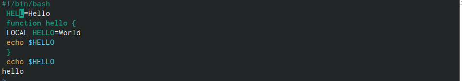

…

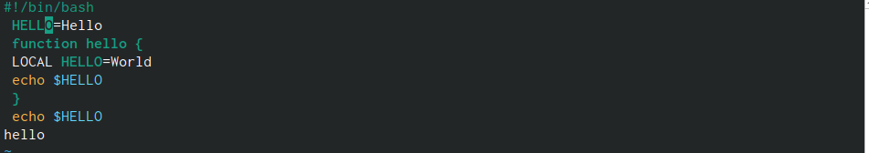

…

7. становите курсор на четвертую строку и сотрите слово LOCAL. Перейдите в режим вставки и наберите следующий текст: local, нажмите Esc для возврата в командный режим

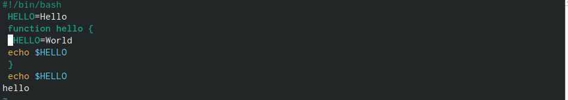

   …

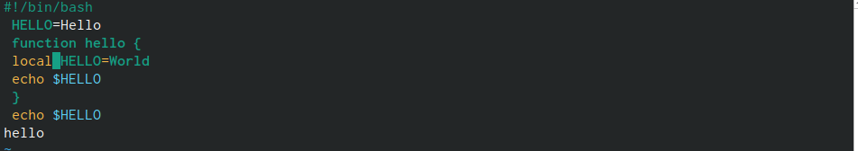

   …

8. Установите курсор на последней строке файла. Вставьте после неё строку, содержащую следующий текст: echo $HELLO

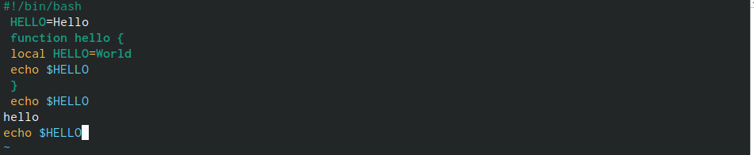

…

9. удалите последнюю строку. Введите команду отмены изменений u для отмены последней команды

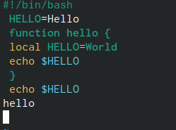

…

[figure not shown]

…

10. Введите символ : для перехода в режим последней строки. Запишите произведённые изменения и выйдите из vi.

## Вывод

- мы молодцы